# Exploratory Analysis of the Tooth Growth dataset

Andrew J. Dyck

## Data Summary

The Tooth Growth dataset includes 60 observations of tooth growth with two additional categorical variables:

- Supplement Type (supp): Either VC or OJ
- Dose (dose): Dose level of Vitamin C

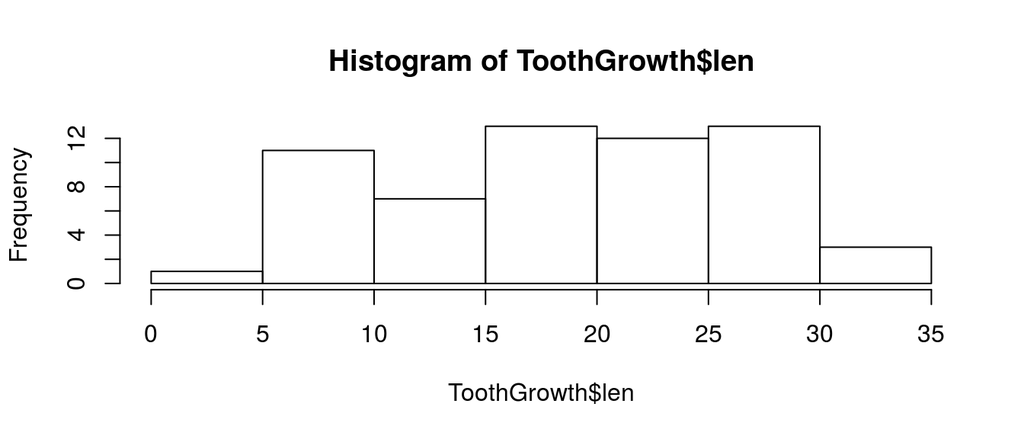

```r
data(ToothGrowth)
hist(ToothGrowth$len)
```

```r
aggregate(ToothGrowth$len, by=list(ToothGrowth$dose), FUN=mean)
```

```
##   Group.1      x
## 1     0.5 10.605
## 2     1.0 19.735
## 3     2.0 26.100
```

```r
aggregate(ToothGrowth$len, by=list(ToothGrowth$supp), FUN=mean)
```

```
##   Group.1        x
## 1      OJ 20.66333
## 2      VC 16.96333
```

```r
aggregate(ToothGrowth$len, by=list(ToothGrowth$supp, ToothGrowth$dose), FUN=mean)
```

```
##   Group.1 Group.2     x
## 1      OJ     0.5 13.23
## 2      VC     0.5  7.98
## 3      OJ     1.0 22.70
## 4      VC     1.0 16.77
## 5      OJ     2.0 26.06
## 6      VC     2.0 26.14
```

The overall distribution for tooth growth appears to be normal, with a fairly wide distribution around a mean of 18.81 and a variance of 58.51. The mean tooth growth appears to differ betwen supplement type and dose. Tests of these mean differences are explored in the following section.

## Statistical Tests

```r
t.test(ToothGrowth$len)$conf.int[1:2]
```

```
## [1] 16.83731 20.78936
```

This is interesting as we can see from the previous section that the group mean for some combinations of Supplement method and dose are outside of this range.

### Dose

For example, let’s investigate 95% confidence intervals for the vitamin C dose (This is just exploratory at this point and I draw no conclusions):

```r
t.test(ToothGrowth[which(ToothGrowth$dose==1.0), 'len'])$conf.int[1:2]
```

```
## [1] 17.66851 21.80149
```

```r
t.test(ToothGrowth[which(ToothGrowth$dose==2.0), 'len'])$conf.int[1:2]
```

```
## [1] 24.33364 27.86636
```

```r
t.test(ToothGrowth[which(ToothGrowth$dose==1.0), 'len'],
       ToothGrowth[which(ToothGrowth$dose==2.0), 'len'],
       alternative = 'l')
```

```
##
##  Welch Two Sample t-test
##
## data:  ToothGrowth[which(ToothGrowth$dose == 1), "len"] and ToothGrowth[which(ToothGrowth$dose == 2), "len"]
## t = -4.9005, df = 37.101, p-value = 9.532e-06
## alternative hypothesis: true difference in means is less than 0
## 95 percent confidence interval:
##      -Inf -4.17387
## sample estimates:
## mean of x mean of y
##    19.735    26.100
```

It seems that we can concluded that average tooth growth is indeed higher with a dose of 2.0 compared to 1.0.

### Supplement method

Next, let’s consider a T-test to test the hypothesis that the mean tooth growth is the same between supplement methods:

```r
t.test(ToothGrowth[which(ToothGrowth$supp=='OJ'), 'len'],
       ToothGrowth[which(ToothGrowth$supp=='VC'), 'len'])
```

```
##
##  Welch Two Sample t-test
##
## data:  ToothGrowth[which(ToothGrowth$supp == "OJ"), "len"] and ToothGrowth[which(ToothGrowth$supp == "VC"), "len"]
## t = 1.9153, df = 55.309, p-value = 0.06063
## alternative hypothesis: true difference in means is not equal to 0
## 95 percent confidence interval:
##  -0.1710156  7.5710156
## sample estimates:
## mean of x mean of y
##  20.66333  16.96333
```

With this sample size, we get a p-value of 0.06 for this T-test, so we cannot say that there is a statistical difference between the OJ and VC delivery methods at the $\alpha = 0.05$ level of confidence. It appears that the supplement method doesn’t make a difference in tooth growth

## Conclusion

The assumptions that are required for this analysis are that the population data does indeed follow a normal distribution. If this assumption is not true, then the application of the T-test would be inappropriate for the analysis here. Additionally, I’ve assumed here that the sample size of 60 guinea pigs is sufficient to make the claims in the paragraph above. In fact, with a p-value on the supplement method of 0.06, it’s likely that if the sample size were to be increased, I may be able to comment on the difference between supplement methods from a statistical perspective with more conviction.